# week1.hw.md.11.2.26

Martin Djamongue

2026-11-02

## 1a: mean function without NA handling

```r
v = c(1:50, 55)
vector_mean <- function( df){
  tot = 0
  for ( element in df){
    tot = tot + element
  }
  return( tot / length(df))
}

vector_mean( v)
```

```
## [1] 26.07843
```

# 1b: mean with NA handled

```r
super_vector_mean <- function( vector , na.rm = F ){
  tot = 0
  for (element in vector){
    if( is.na(element)){
      if(na.rm){
        next
      }else{
        return( NA)
      }
    }
    tot = tot +element
  }
   n = sum( !is.na(vector))
  return( tot / n)
}

super_vector_mean(v , na.rm = T)
```

```
## [1] 26.07843
```

```r
mean( v , na.rm =F)
```

```
## [1] 26.07843
```

##### My loop base function for “mean” are expected to agree because I included lines that handle presence of NA values within passed vector during iteration. The final sample size is also calculated by first turning the NAs into logicals ( TRUE/FALSE) then summing , which adds all the TRUEs(1s) to produce actual sample size since the FALSEs will be 0s.

# 1c: accessing data from DuckDB repository

```r
library(repoquet)
library(DBI)
library(duckdb)
library(ggplot2)


config_path <- "repoquet_public_example/repository_config.R"
cfg <- load_repository_config( config_path)
temp_dir <- file.path(cfg$FormattedDBPath, "duckdb_temp")
dir.create(temp_dir, recursive = TRUE, showWarnings = FALSE)

con <- open_duckdb(
  FormattedDBPath = cfg$FormattedDBPath,
  DBName = cfg$DBName,
  TempDirPath = temp_dir,
  GB = cfg$DuckDB_GB,
  ReadOnly = TRUE
)


nhanes_tables<- DBI::dbListTables(con)
nhanes_tables <- sort(grep("^NHANES_" , nhanes_tables, value = TRUE, ignore.case = TRUE))
head(nhanes_tables, 5)
```

```
## [1] "NHANES_AA"  "NHANES_AAS" "NHANES_ACQ" "NHANES_AGP" "NHANES_AGQ"
```

```r
nhanes_table <- nhanes_tables[32]
DBI::dbGetQuery(con, paste0("DESCRIBE ", nhanes_table))
```

```
##     column_name column_type null  key default extra
## 1          SEQN      DOUBLE  YES <NA>    <NA>  <NA>
## 2      BMAEXLEN      DOUBLE  YES <NA>    <NA>  <NA>
## 3      BMAEXSTS      DOUBLE  YES <NA>    <NA>  <NA>
## 4      BMAEXCMT      DOUBLE  YES <NA>    <NA>  <NA>
## 5         BMXWT      DOUBLE  YES <NA>    <NA>  <NA>
## 6         BMIWT      DOUBLE  YES <NA>    <NA>  <NA>
## 7      BMXRECUM      DOUBLE  YES <NA>    <NA>  <NA>
## 8      BMIRECUM      DOUBLE  YES <NA>    <NA>  <NA>
## 9       BMXHEAD      DOUBLE  YES <NA>    <NA>  <NA>
## 10      BMIHEAD      DOUBLE  YES <NA>    <NA>  <NA>
## 11        BMXHT      DOUBLE  YES <NA>    <NA>  <NA>
## 12        BMIHT      DOUBLE  YES <NA>    <NA>  <NA>
## 13       BMXBMI      DOUBLE  YES <NA>    <NA>  <NA>
## 14       BMXLEG      DOUBLE  YES <NA>    <NA>  <NA>
```

[output cut: 41 more lines]

```r
bmi_data <- DBI::dbGetQuery(con, paste0( "SELECT * FROM ", DBI::dbQuoteIdentifier(con, nhanes_table)))

head(bmi_data)
```

```
##   SEQN BMAEXLEN BMAEXSTS BMAEXCMT BMXWT BMIWT BMXRECUM BMIRECUM BMXHEAD BMIHEAD
## 1    1      289        1       NA  12.5     3     93.2       NA      NA      NA
## 2    2      376        1       NA  75.4    NA       NA       NA      NA      NA
## 3    3      199        1       NA  32.9    NA       NA       NA      NA      NA
## 4    4      170        1       NA  13.3    NA     87.1       NA      NA      NA
## 5    5      277        1       NA  92.5    NA       NA       NA      NA      NA
## 6    6      252        1       NA  59.2    NA       NA       NA      NA      NA
##   BMXHT BMIHT BMXBMI BMXLEG BMILEG BMXCALF BMICALF BMXARML BMIARML BMXARMC
## 1  91.6    NA  14.90     NA     NA      NA      NA    18.6      NA    15.2
## 2 174.0    NA  24.90     NA      1    37.5      NA    38.2      NA    29.8
## 3 136.6    NA  17.63   34.1     NA    29.0      NA    25.5      NA    19.7
## 4    NA    NA     NA     NA     NA      NA      NA    20.4      NA    16.4
## 5 178.3    NA  29.10   45.2     NA    42.6      NA    39.7      NA    35.8
## 6 162.0    NA  22.56   39.7     NA    34.0      NA    34.5      NA    26.0
##   BMIARMC BMXWAIST BMIWAIST BMXTHICR BMITHICR BMXTRI BMITRI BMXSUB BMISUB
```

[output cut: 27 more lines]

```r
str(bmi_data)
```

```
## 'data.frame':    119926 obs. of  55 variables:
##  $ SEQN        : num  1 2 3 4 5 6 7 8 9 10 ...
##  $ BMAEXLEN    : num  289 376 199 170 277 252 303 257 178 218 ...
##  $ BMAEXSTS    : num  1 1 1 1 1 1 1 1 1 1 ...
##  $ BMAEXCMT    : num  NA NA NA NA NA NA NA NA NA NA ...
##  $ BMXWT       : num  12.5 75.4 32.9 13.3 92.5 ...
##  $ BMIWT       : num  3 NA NA NA NA NA NA NA NA NA ...
##  $ BMXRECUM    : num  93.2 NA NA 87.1 NA NA NA NA NA NA ...
##  $ BMIRECUM    : num  NA NA NA NA NA NA NA NA NA NA ...
##  $ BMXHEAD     : num  NA NA NA NA NA NA NA NA NA NA ...
##  $ BMIHEAD     : num  NA NA NA NA NA NA NA NA NA NA ...
##  $ BMXHT       : num  91.6 174 136.6 NA 178.3 ...
##  $ BMIHT       : num  NA NA NA NA NA NA NA NA NA NA ...
##  $ BMXBMI      : num  14.9 24.9 17.6 NA 29.1 ...
##  $ BMXLEG      : num  NA NA 34.1 NA 45.2 39.7 43 41.6 42.2 46.6 ...
```

[output cut: 41 more lines]

```r
#column to calculate mean from
weight_in_kg <- bmi_data$BMXWT
super_vector_mean( weight_in_kg , na.rm = T)
```

```
## [1] 62.86981
```

```r
#regular mean function
mean( weight_in_kg , na.rm = T)
```

```
## [1] 62.86981
```

## 1d: Testing for correlation between the BMXBMI vs BMXWAIST

Ho: correlation between body mass index and waist circumference = 0 Ha: correlation between body mass index and waist circumference != 0

```r
body_mass_index <- bmi_data $BMXBMI
waist_circum <- bmi_data $ BMXWAIST

cor.test( body_mass_index , waist_circum)
```

```
##
##  Pearson's product-moment correlation
##
## data:  body_mass_index and waist_circum
## t = 827.9, df = 105025, p-value < 2.2e-16
## alternative hypothesis: true correlation is not equal to 0
## 95 percent confidence interval:
##  0.9303913 0.9319985
## sample estimates:
##       cor
## 0.9311994
```

From the cor.test results; there’s a positive correlation ( r =0.9311994 ) between body mass index and waist circumference. As BMI increases, waist circumference also increases. t = 827.9 and p-value < 2.2e-16 suggest there’s evidence for the alternative hypothesis. This shows relationship does not imply causation, but rather suggest it’s worth investigating further.

## 2a. Downloading dataset from GEO using the GEODataDownload function.

```r
library(DESeq2)
library(limma)
library(data.table)
library(GEOquery)
library(org.Hs.eg.db)
library(DT)

#------Function--

GEODataDownload <- function(DS, gpl, gsm, PlateAnnotInfo, GenerateMetaData, Technology){
  library(DESeq2); library(limma); library(data.table)
  if(Technology == "Array"){
    gset <- getGEO(DS)
    if(length(gset) > 1) idx <- grep(gpl, attr(gset, "names")) else idx <- 1
    gset <- gset[[idx]]
    fvarLabels(gset) <- make.names(fvarLabels(gset))
    comp <- gsub(" ", "", gsm)
    comp <- gsub(",", "", comp)
    gsms <- paste0(comp)
    #### Set up raw names ####
    sml <- c()
    for(i in 1:nchar(gsms)){ sml[i] <- substr(gsms,i,i)}
    ex <- exprs(gset)
    qx <- as.numeric(quantile(ex, c(0., 0.25, 0.5, 0.75, 0.99, 1.0), na.rm=T))
    LogC <- (qx[5] > 100) ||
      (qx[6]-qx[1] > 50 && qx[2] > 0) ||
      (qx[2] > 0 && qx[2] < 1 && qx[4] < 2)
    if(LogC){ ex[which(ex <= 0)] <- NaN
    exprs(gset) <- log2(ex) }
    sml <- paste("G", sml, sep="")
    f1 <- as.factor(sml)
    gset$description2 <- f1
    design <- model.matrix(~description2 + 0, gset)
    colnames(design) <- levels(f1)
    fit <- lmFit(gset, design)
    cont.matrix <- makeContrasts(G1-G0, levels = design)
    fit2 <- contrasts.fit(fit, cont.matrix)
    fit2 <- eBayes(fit2, 0.01)
    tT <- topTable(fit2, adjust="fdr", sort.by = "B", number = 25000000000)
    #### subset ####
    ex2 <- data.table(subset(tT, select=c("ID", "logFC", "P.Value", "adj.P.Val")))
    ex2$ID <- as.character(ex2$ID)
    #### annotate with gene names ####
    plat <- PlateAnnotInfo[GPLID == gpl,][,!"GPLID", with = FALSE]
    if(nrow(plat) == 0){ print(paste("There is no annotation information available for", gpl)) }
    plat$ID <- as.character(plat$ID)
    plat <- plat[!duplicated(plat$ID),]
    ex2 <- merge(plat, ex2, by = "ID")
    ex2$ID <- as.character(ex2$ID)
    exraw <- data.table(ex)
    exraw$ID <- as.character(rownames(ex))
    #### annotate raw data with gene names ####
    ex2 <- merge(ex2, exraw, by = "ID")
    #### Generate Meta Data ####
    Pdat <- pData(gset)
    #### Add Meta data ####
    Pdat <- as.data.table(Pdat)
    return(list(Data = ex2, MetaData = Pdat))
  }

  if(Technology == "RNAseq"){
    ACC <- paste("acc=", DS, sep = "")
    file <- paste("file=", DS, "_raw_counts_GRCh38.p13_NCBI.tsv.gz", sep = "")
    comp <- gsub(" ", "", gsm)
    comp <- gsub(",", "", comp)
    gsms <- paste0(comp)
    #### Set up DEG names ####
    urld <- "https://www.ncbi.nlm.nih.gov/geo/download/?format=file&type=rnaseq_counts"
    path <- paste(urld, ACC, file, sep="&");
    tbl <- as.matrix(data.table::fread(path, header=T, colClasses="integer"), rownames="GeneID")
    exraw <- tbl
    apath <- paste(urld, "type=rnaseq_counts", "file=Human.GRCh38.p13.annot.tsv.gz", sep="&")
    annot <- tryCatch(data.table::fread(apath, header=T, quote="", stringsAsFactors=F, data.table=F),
                      error = function(e) NULL)
    ## FALLBACK (only change to the notes' function): if NCBI serves a captcha page instead of the
    ## annotation file, use NCBI's Homo_sapiens.gene_info (the same GeneID/Symbol/description source)
    if(is.null(annot) || !all(c("GeneID", "Symbol", "Description") %in% names(annot))){
      annot <- data.table::fread("https://ftp.ncbi.nlm.nih.gov/gene/DATA/GENE_INFO/Mammalia/Homo_sapiens.gene_info.gz",
                                 header=T, quote="", stringsAsFactors=F, data.table=F)
      names(annot)[names(annot) == "#tax_id"] <- "tax_id"
      annot <- annot[, c("GeneID", "Symbol", "description")]
      names(annot)[3] <- "Description"
    }
    rownames(annot) <- annot$GeneID
    sml <- strsplit(gsms, split="")[[1]]
    sel <- which(sml != "X")
    sml <- sml[sel]
    tbl <- tbl[ ,sel]
    gs <- factor(sml)
    groups <- make.names(c("Ctrl", "Tx"))
    levels(gs) <- groups
    sample_info <- data.frame(Group = gs, row.names = colnames(tbl))
    keep <- rowSums( tbl >= 10 ) >= min(table(gs))
    tbl <- tbl[keep, ]
    ds <- DESeqDataSetFromMatrix(countData=tbl, colData=sample_info, design= ~Group)
    ds <- DESeq(ds, test="Wald", sfType="poscount")
    r <- results(ds, contrast=c("Group", groups[2], groups[1]), alpha=0.05, pAdjustMethod ="fdr")
    tT <- r[order(r$padj)[1:length(r$padj)],]
    tT <- merge(as.data.frame(tT), annot, by=0, sort=F)
    tT <- subset(tT, select=c("GeneID","padj","pvalue","lfcSE","stat","log2FoldChange","baseMean","Symbol","Description"))
    #### subset ####
    ex2 <- data.table(subset(tT, select=c("GeneID", "Symbol", "Description", "log2FoldChange", "pvalue", "padj")))
    #### Adjust column names ####
    setnames(ex2, c("GeneID", "Symbol", "Description"), c("ENTREZID", "SYMBOL", "GENENAME"))
    #### Get Raw data ####
    GeneID <- as.integer(rownames(exraw))
    exraw <- as.data.table(exraw)
    #### Update column names ####
    exraw$ENTREZID <- GeneID
    #### merge FC and raw data together ####
    mer <- merge(ex2, exraw, by = "ENTREZID")
    return(mer)
  }
}
```

## 2a: downloading and saving data as .txt in working directory

```r
#loading data
gse <- getGEO("GSE226151")
metadta <- pData(gse[[1]])


RNAseqData <- GEODataDownload(DS = "GSE226151",
                              gpl = "GPL24676",
                              gsm = "00000000000000000000XXXXXXXXXXXXXXXXXXX1111111111111111111",
                              PlateAnnotInfo = "Only needed if the data was generated using MicroArrays",
                              GenerateMetaData = "Only needed if the data was generated using MicroArrays",
                              Technology = "RNAseq")

fwrite(RNAseqData, "GSE226151_Sarcopenia_data.txt", sep = "\t")

gse226151_data <- fread("GSE226151_Sarcopenia_data.txt", sep = "\t")

head(gse226151_data)
```

```
##    ENTREZID   SYMBOL                                GENENAME log2FoldChange
##       <int>   <char>                                  <char>          <num>
## 1:        1     A1BG                  alpha-1-B glycoprotein    -0.07684536
## 2:        2      A2M                   alpha-2-macroglobulin     0.09696683
## 3:       12 SERPINA3                serpin family A member 3     0.96019599
## 4:       14     AAMP angio associated migratory cell protein    -0.07594455
## 5:       16    AARS1                alanyl-tRNA synthetase 1    -0.10216643
## 6:       18     ABAT        4-aminobutyrate aminotransferase     0.14392469
##        pvalue      padj GSM7065818 GSM7065819 GSM7065820 GSM7065821 GSM7065822
##         <num>     <num>      <int>      <int>      <int>      <int>      <int>
## 1: 0.77973223 0.9294321         15          7         14         26          5
## 2: 0.46004948 0.7956254       4439       2871       5531       3582       3099
## 3: 0.04308457 0.3860397        164         35         44         14          5
## 4: 0.51203113 0.8197383       1330       1490        838        982        812
## 5: 0.09790573 0.5129091       1213        945       1618       1473       1266
```

[output cut: 65 more lines]

## 2b: adding column to data frame

```r
gse226151_data $ Subset_Comparison <- "Sarcopenia-HealthyAged"
```

An additional column describing the treatment comparison, it becomes easier to filter when making multiple analysis especially on same genes across multiple contrast and becomes a unique character for “grouping by” when combining multiple differential expression analyses.

## 2c: Average expression level for each sample (column) in the raw expression

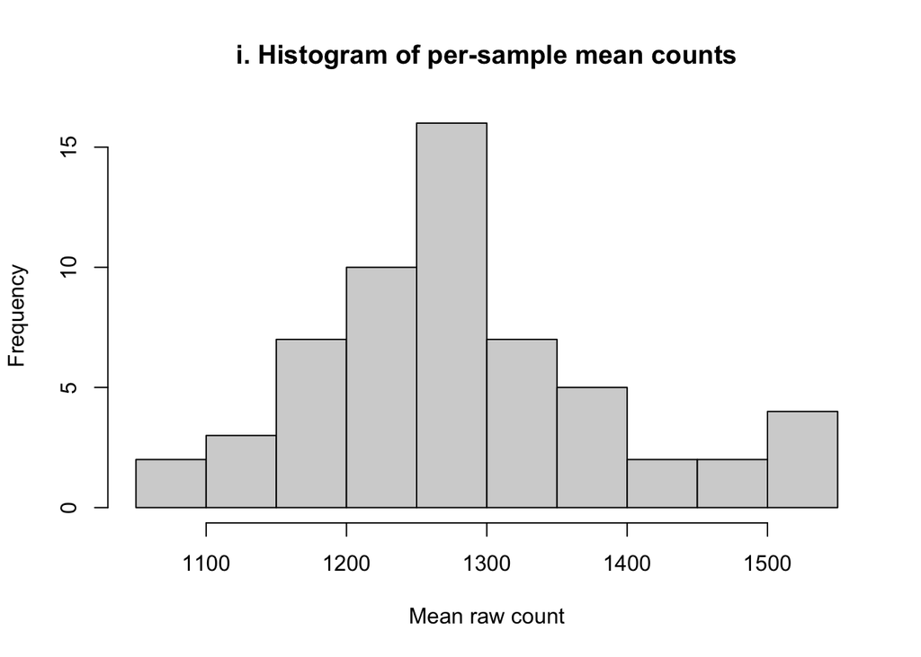

```r
 dfr_raw <- as.matrix (gse226151_data[,7:64]);rownames(dfr_raw) <- gse226151_data$SYMBOL

raw_averages <- colMeans( dfr_raw , na.rm = T)

 #histogram visualization
 hist(raw_averages, main = "i. Histogram of per-sample mean counts", xlab = "Mean raw count")
```

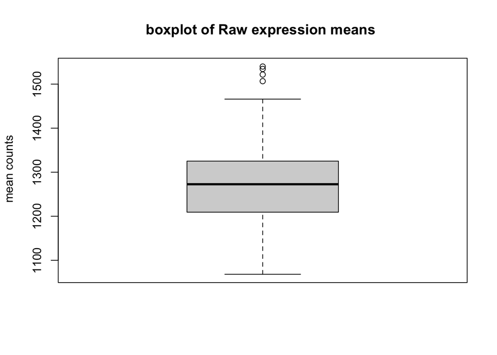

```r
 # Boxplot

 boxplot( raw_averages , main = "boxplot of Raw expression means " , ylab = " mean counts")
```

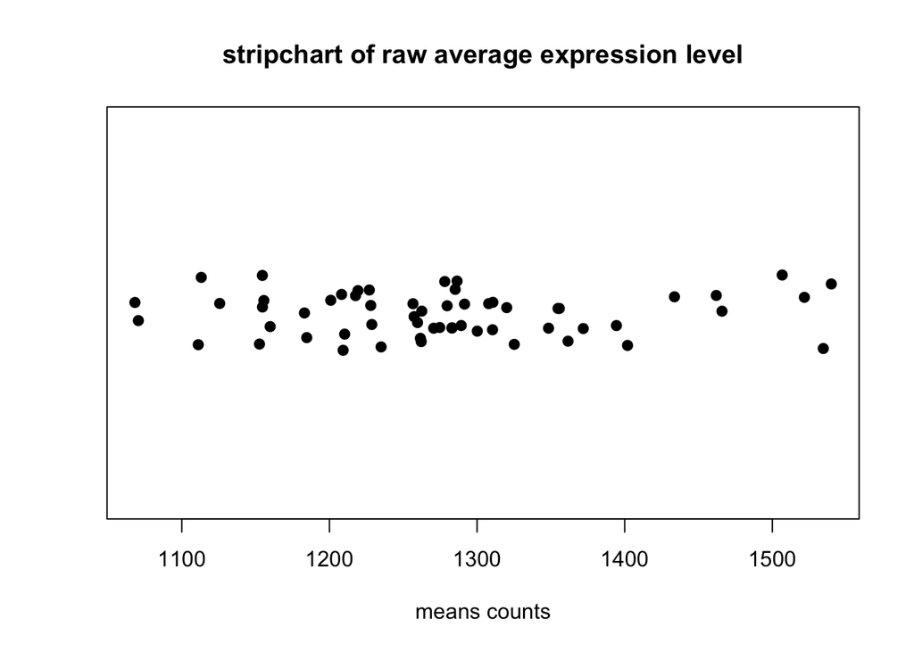

```r
# Stripchart
 stripchart( raw_averages ,  method = "jitter", pch = 19, main = "stripchart of raw average expression level" , xlab = "means counts")
```

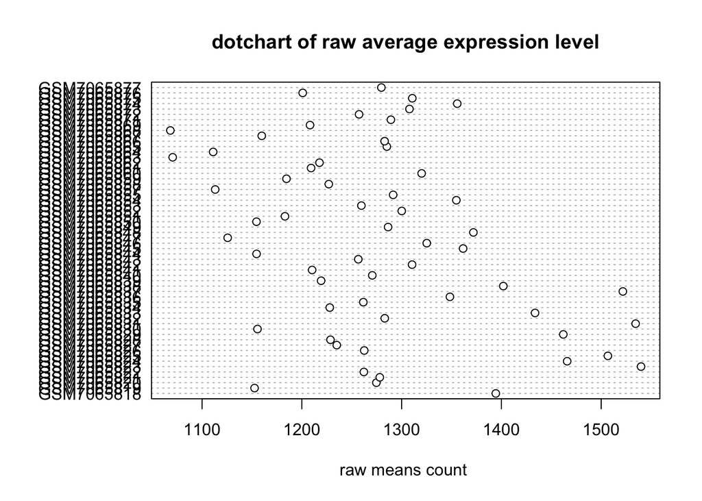

```r
#Dotchart

 dotchart( raw_averages, labels(raw_averages) , xlab = "raw means count " , main = "dotchart of raw average expression level")
```

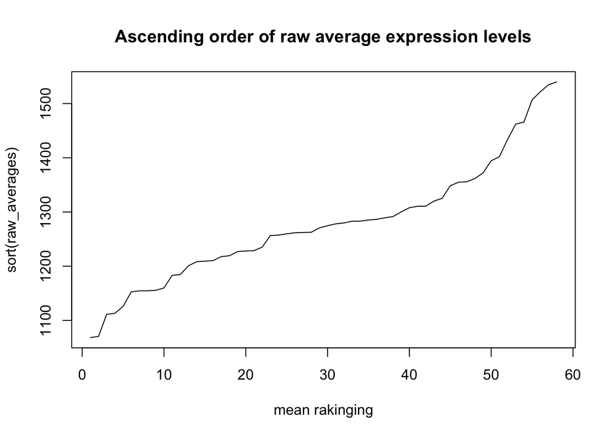

```r
#Sorted in ascending order (line or point plot)

 plot( sort (raw_averages) ,
       xlab = "mean rakinging",
       main = "Ascending order of raw average expression levels",
       type = "l"
       )
```